# fullsibQTL Tutorial

### Graphical comparision between `(c)im_scan`

The IM and CIM mapping results can be compared in a graphical way with the following codes:

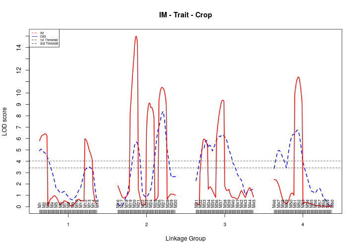

```r
plot(im,cim, lty = c(2,1), lwd = 2, incl.mkr = "name", cex.incl = 0.7, gap=50,
     cex.axis = 0.8, col = c("blue","red"),
     main = "IM - Trait - Crop",
     xlab = "Linkage Group",
     ylab = "LOD score",
     yaxt = "n",
     ylim = c(0,15))
axis(side=2,at=seq(0,15,1),lwd=1)
abline(h = im.peak1, lty = 2, lwd = 0.75)
abline(h = cim.peak1, lty = 2, lwd = 0.75)
legend("topleft", lty=c(2,1,2,2), cex=0.5, col=c("red","blue","black","black"), legend=c("IM","CIM","1st Threshold","2nd Threshold"))
```

```r
## Adding QTLs
```

### Adding QTL location to the graphic

Our QTLs are the following:

```r
print(cim,lg=1,pos=c("loc13","M12"))
```

```
##       lg pos.cM      LOD model
## loc13  1     13 6.420684     0
## M12    1    110 5.970667     0
```

```r
print(cim,lg=2,pos=c("loc45","loc77","loc108"))
```

```
##        lg pos.cM       LOD model
## loc45   2     45 14.985451     0
## loc77   2     77  9.115538     0
## loc108  2    108 10.496445     0
```

```r
print(cim,lg=3,pos=c("M33","loc65"))
```

```
##       lg pos.cM      LOD model
## M33    3     20 5.960747     0
## loc65  3     65 9.367385     0
```

```r
print(cim,lg=4,pos="M52")
```

```
##     lg pos.cM      LOD model
## M52  4     60 11.39792     0
```

To add them to the graphic we can use the function `points` as follows. Knowing that the `gap` space is `50`, we can add this to the total size of each LG and get the position. The points will be localized at:

```r
points.loc <- c(13,110,45,77,108,20,65,60)
points.loc <- points.loc + c(0,0,
                             140+50,140+50,140+50,
                             140+50+140+50,140+50+140+50,
                             140+50+140+50+140+50)
```

Therefore:

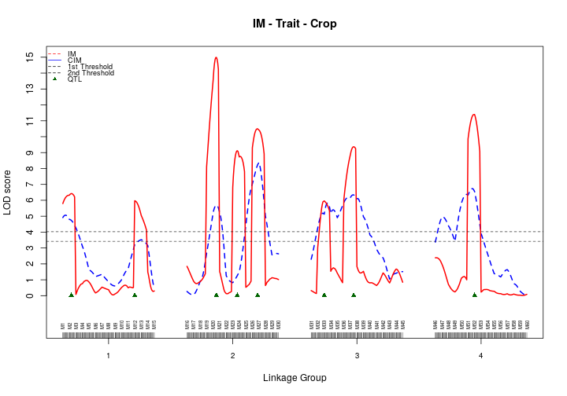

```r
plot(im,cim, lty = c(2,1), lwd = 2, incl.mkr = "name", cex.incl = 0.5, gap=50,
     cex.axis = 0.8, col = c("blue","red"),
     main = "IM - Trait - Crop",
     xlab = "Linkage Group",
     ylab = "LOD score",
     yaxt = "n",
     ylim = c(-2,15))
axis(side=2,at=seq(0,15,1),lwd=1)
abline(h = im.peak1, lty = 2, lwd = 0.75)
abline(h = cim.peak1, lty = 2, lwd = 0.75)
points(y=rep(0,8),x=points.loc, pch=17, col="dark green")
legend("topleft", lty=c(2,1,2,2,0), cex=0.75, pch = c(NA,NA,NA,NA,17),col = c("red", "blue", "black", "black", "dark green"), legend = c("IM","CIM","1st Threshold","2nd Threshold","QTL"),bty='n',y.intersp=.75)
```

## References

Belsley, D. A., Edwin K., and Roy E. W. (2005). *Regression diagnostics: Identifying influential data and sources of collinearity*. Vol. 571. John Wiley | Sons.

Cockerham, C. C. (1954). An extension of the concept of partitioning hereditary variance for analysis of covariances among relatives when epistasis is present. *Genetics* 39(6), 859.

Chen, L., and Storey, J. D. (2006). Relaxed significance criteria for linkage analysis. *Genetics*, 173(4), 2371-2381.

Churchill, G. A., and Doerge, R. W. (1994). Empirical threshold values for quantitative trait mapping. *Genetics*, 138(3), 963-971.

Gazaffi, R., Margarido, G. R., Pastina, M. M., Mollinari, M., Garcia, A. A. F. (2014). A model for quantitative trait loci mapping, linkage phase, and segregation pattern estimation for a full-sib progeny. *Tree Genetics & Genomes*, 10(4), 791-801.

Grattapaglia, D., and Sederoff, R. (1994). Genetic linkage maps of Eucalyptus grandis and Eucalyptus urophylla using a pseudo-testcross: mapping strategy and RAPD markers. *Genetics*, 137(4), 1121-1137.

Margarido, G. R. A., Souza, A.P. and Garcia, A. A. F. OneMap: software for genetic mapping in outcrossing species. *Hereditas* 144, 78-79, 2007.

Wu, R., Ma, C.X., Painter, I. and Zeng, Z.-B. Simultaneous maximum likelihood estimation of linkage and linkage phases in outcrossing species. *Theoretical Population Biology* 61, 349-363, 2002a.

Wu, R., Ma, C.-X., Wu, S. S. and Zeng, Z.-B. Linkage mapping of sex-specific differences. *Genetical Research* 79, 85-96, 2002b.